# Introdução ao R

Exercício e soluções

Tiago Ferreira

**EXERCÍCIO 1**

1. Iniciar o R e verificar o local ou diretório de trabalho. Colocar nesse local o ficheiro de dados “dogs.csv”;

```r
getwd()
```

```
## [1] "G:/My Drive/FPCEUP/AtividadeDocente/R_crash_course/R crash course_Exer"
```

2. Importar a base de dados dogs, atribuindo essa estrutura de dados ao valor DOGS. Ver datalhes da base de dados em: https://data.world/len/intelligence-of-dogs;

```r
DOGS <- read.csv("G:\\My Drive\\FPCEUP\\AtividadeDocente\\R_crash_course\\R crash course_Data\\dogs.csv")
# pode usar a choose.files() para selecionar mais facilmente o ficheiro
```

3. Verificar classe, estrutura, nomes das variáveis e primeiras linhas/observações de DOGS;

```r
class(DOGS)
```

```
## [1] "data.frame"
```

```r
str(DOGS)
```

```
## 'data.frame':    136 obs. of  5 variables:
##  $ Breed         : chr  "Border Collie" "Poodle" "German Shepherd" "Golden Retriever" ...
##  $ Classification: chr  "bright" "bright" "bright" "bright" ...
##  $ obey          : num  1.58 1.86 1.96 1.8 1.78 ...
##  $ reps_lower    : int  1 1 1 1 1 1 1 1 1 1 ...
##  $ reps_upper    : int  4 4 4 4 4 4 4 4 4 4 ...
```

```r
names(DOGS)
```

```
## [1] "Breed"          "Classification" "obey"           "reps_lower"
## [5] "reps_upper"
```

```r
head(DOGS)
```

```
##               Breed Classification     obey reps_lower reps_upper
## 1     Border Collie         bright 1.576044          1          4
## 2            Poodle         bright 1.856408          1          4
## 3   German Shepherd         bright 1.962500          1          4
## 4  Golden Retriever         bright 1.798154          1          4
## 5 Doberman Pinscher         bright 1.783401          1          4
## 6 Shetland Sheepdog         bright 1.736183          1          4
```

4. Visualizar lista das raças na base de dados;

```r
DOGS$Breed
```

```
##   [1] "Border Collie"                   "Poodle"
##   [3] "German Shepherd"                 "Golden Retriever"
##   [5] "Doberman Pinscher"               "Shetland Sheepdog"
##   [7] "Labrador Retriever"              "Papillon"
##   [9] "Rottweiler"                      "Australian Cattle Dog"
##  [11] "Pembroke Welsh Corgi"            "Miniature Schnauzer"
##  [13] "English Springer Spaniel"        "Belgian Shepherd Dog (Tervuren)"
##  [15] "Schipperke"                      "Belgian Sheepdog"
##  [17] "Collie"                          "Keeshond"
##  [19] "German Shorthaired Pointer"      "Flat-Coated Retriever"
##  [21] "English Cocker Spaniel"          "Standard Schnauzer"
##  [23] "Brittany"                        "Cocker Spaniel"
##  [25] "Weimaraner"                      "Belgian Malinois"
##  [27] "Bernese Mountain Dog"            "Pomeranian"
##  [29] "Irish Water Spaniel"             "Vizsla"
```

[output cut: 53 more lines]

5. Fazer sumário das variáveis em DOGS;

```r
summary(DOGS)
```

```
##     Breed           Classification          obey            reps_lower
##  Length:136         Length:136         Min.   :-1.93216   Min.   : 1.00
##  Class :character   Class :character   1st Qu.:-0.78015   1st Qu.:16.00
##  Mode  :character   Mode  :character   Median :-0.07389   Median :26.00
##                                        Mean   : 0.00000   Mean   :25.59
##                                        3rd Qu.: 0.79313   3rd Qu.:26.00
##                                        Max.   : 1.96250   Max.   :81.00
##                                        NA's   :11
##    reps_upper
##  Min.   :  4.00
##  1st Qu.: 25.00
##  Median : 40.00
##  Mean   : 41.51
##  3rd Qu.: 40.00
##  Max.   :100.00
##
```

6. Criar e visualizar o objeto “dif_reps” definido pela diferença entre variáveis “reps_upper” e “reps_lower”;

```r
dif_reps <- DOGS$reps_upper - DOGS$reps_lower
dif_reps
```

```
##   [1]  3  3  3  3  3  3  3  3  3  3 10 10 10 10 10 10 10 10 10 10 10 10 10 10 10
##  [26] 10 10 10 10 10 10  9  9  9  9  9  9  9  9  9  9  9  9  9  9  9  9  9  9  9
##  [51]  9  9  9  9  9  9  9  9  9  9  9 14 14 14 14 14 14 14 14 14 14 14 14 14 14
##  [76] 14 14 14 14 14 14 14 14 14 14 14 14 14 14 14 14 14 14 14 14 14 14 14 14 14
## [101] 14 14 14 39 39 39 39 39 39 39 39 39 39 39 39 39 39 39 39 39 39 39 39 39 39
## [126] 19 19 19 19 19 19 19 19 19 19 19
```

7. Utilizar a função plot() para visualizar a variáveis “Classification”. Use as.factor() se necessário;

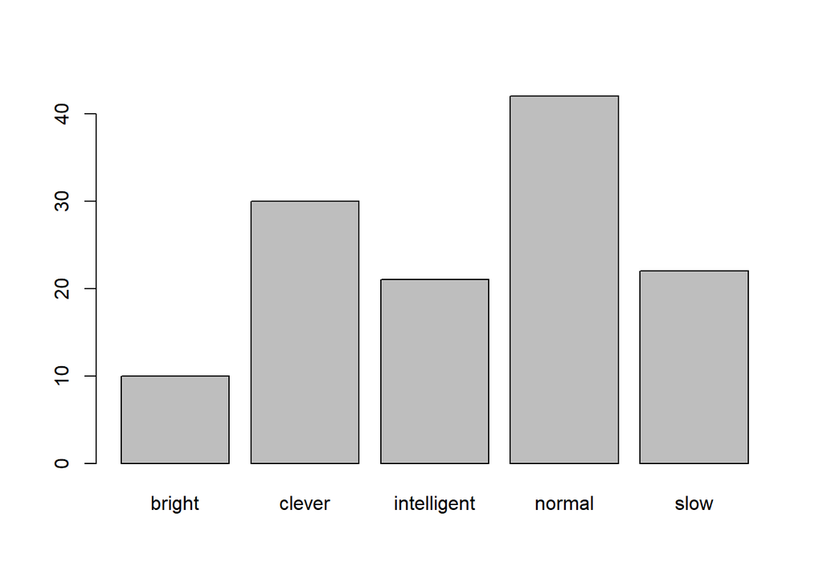

```r
plot(as.factor(DOGS$Classification))
```

8. Fazer um histograma para a variável “obey”“;

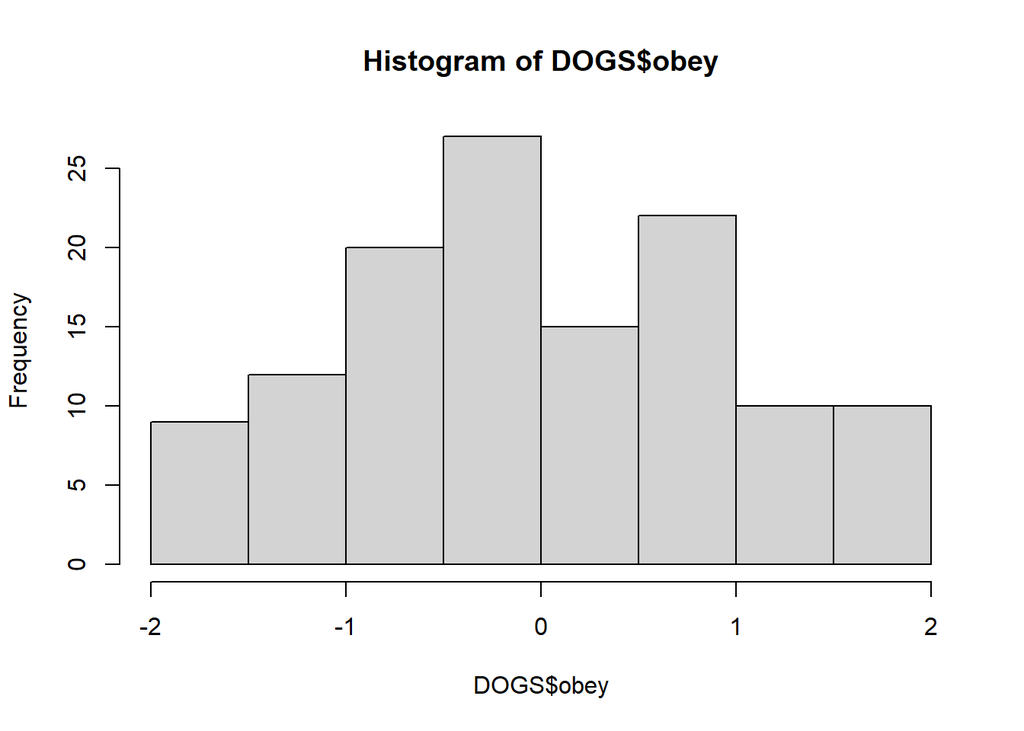

```r
hist(DOGS$obey)
```

9. Instalar (se necessário) e carregar o pacote “psych”;

```r
install.packages("psych")
library(psych)
```

10. Usar as funcionalidades deste pacote para calcular estatística descritiva básica e correlações para as variáveis “obey”, “reps_lower” e “reps_upper”;

```r
psych::describe(DOGS[3:5])
```

```
##            vars   n  mean   sd median trimmed   mad   min    max range skew
## obey          1 125  0.00  1.0  -0.07    0.00  1.21 -1.93   1.96  3.89 0.02
## reps_lower    2 136 25.59 20.5  26.00   22.56 14.83  1.00  81.00 80.00 1.36
## reps_upper    3 136 41.51 28.2  40.00   39.09 22.24  4.00 100.00 96.00 0.79
##            kurtosis   se
## obey          -0.86 0.09
## reps_lower     1.69 1.76
## reps_upper    -0.56 2.42
```

```r
corr.test(DOGS[3:5])
```

```
## Call:corr.test(x = DOGS[3:5])
## Correlation matrix
##             obey reps_lower reps_upper
## obey        1.00      -0.95      -0.91
## reps_lower -0.95       1.00       0.95
## reps_upper -0.91       0.95       1.00
## Sample Size
##            obey reps_lower reps_upper
## obey        125        125        125
## reps_lower  125        136        136
## reps_upper  125        136        136
## Probability values (Entries above the diagonal are adjusted for multiple tests.)
##            obey reps_lower reps_upper
## obey          0          0          0
## reps_lower    0          0          0
## reps_upper    0          0          0
##
##  To see confidence intervals of the correlations, print with the short=FALSE option
```

11. Criar um boxplot que represente o nível de obediência por cada classificação de raça;

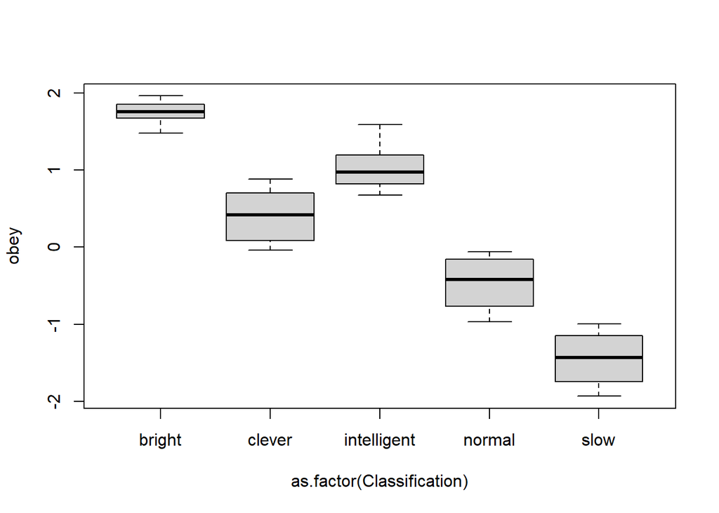

```r
plot(obey ~ as.factor(Classification), data=DOGS)
```

12. Criar um modelo para verificar a existência de um efeito da classificação no nível de obediência. Clarificar que pares de classificações apresentam diferenças significativas em termos do seu nível de obediência;

```r
model1 <- aov(obey ~ Classification, data=DOGS)
summary(model1)
```

```
##                 Df Sum Sq Mean Sq F value Pr(>F)
## Classification   4 112.96  28.240   306.9 <2e-16 ***
## Residuals      120  11.04   0.092
## ---
## Signif. codes:  0 '***' 0.001 '**' 0.01 '*' 0.05 '.' 0.1 ' ' 1
## 11 observations deleted due to missingness
```

```r
TukeyHSD(model1)
```

```
##   Tukey multiple comparisons of means
##     95% family-wise confidence level
##
## Fit: aov(formula = obey ~ Classification, data = DOGS)
##
## $Classification
##                          diff        lwr        upr p adj
## clever-bright      -1.3510353 -1.6578071 -1.0442634 0e+00
## intelligent-bright -0.7121774 -1.0349654 -0.3893895 1e-07
## normal-bright      -2.2203777 -2.5159904 -1.9247649 0e+00
## slow-bright        -3.1904502 -3.5108630 -2.8700375 0e+00
## intelligent-clever  0.6388579  0.3998232  0.8778926 0e+00
## normal-clever      -0.8693424 -1.0701717 -0.6685131 0e+00
## slow-clever        -1.8394149 -2.0752323 -1.6035976 0e+00
## normal-intelligent -1.5082002 -1.7327342 -1.2836662 0e+00
## slow-intelligent   -2.4782728 -2.7345792 -2.2219665 0e+00
## slow-normal        -0.9700726 -1.1911784 -0.7489668 0e+00
```